# Heart rate detection and stress - Preliminary result document

Tamas Nagy

2021-10-07

The following analysis report contains the descriptive and inferential statistics for the experiment that investigated how physiological and subjective arousal might be mediated by cardioceptive accuracy.

# Experiment data processing

## Calculate cardioreceptive metrics

XX stands for 25,35,50 With the average calculated for each pearson.

Cronbach alpha for cardioceptive accuracy: 0.94 Cronbach alpha for cardioceptive bias: 0.94

# Sample characteristics

|  | Value (SD) | Range |
| --- | --- | --- |
| N | 67 (-) | --- |
| Male % | 50.7 (-) | --- |
| Mean age in years | 22.2 (2.2) | 19.0-28.0 |
| Mean STAI-S Baseline | 13.0 (7.5) | 0.0-33.0 |
| Mean BMI in kg/m<sup>2</sup> | 23.1 (3.2) | 17.8-31.5 |
| Mean Bodyfat % | 24.2 (8.3) | 5.2-49.0 |
| Mean resting HR in bpm | 76.8 (10.7) | 54.0-101.0 |

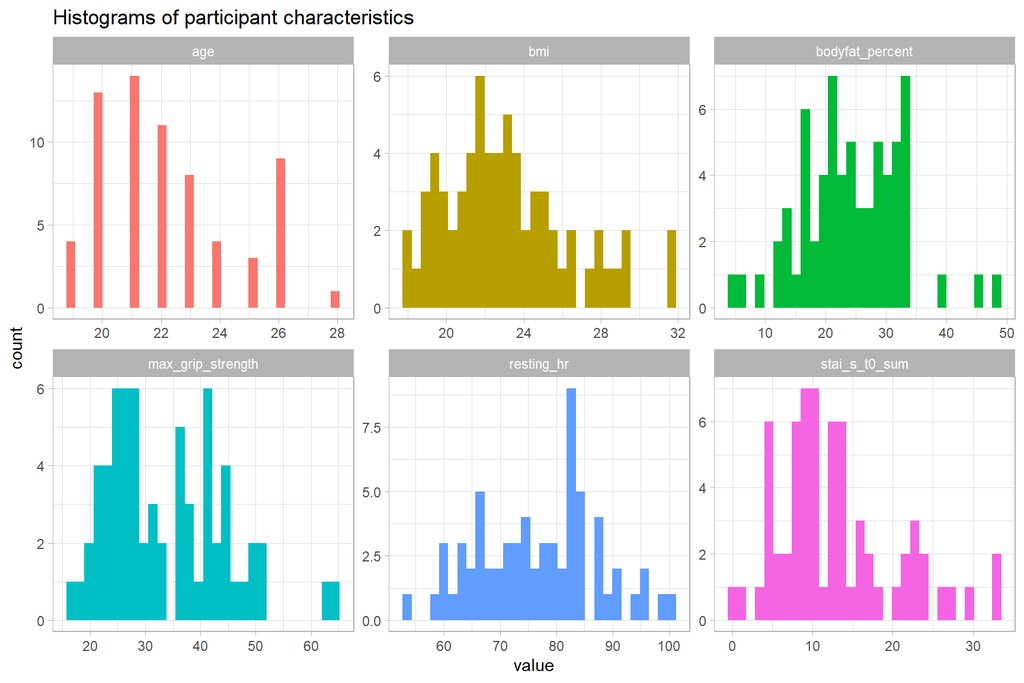

# Subjective response to stress

We tested if the tasks were perceived as stressful.

## STAI-S

Controlling for the baseline level of anxiety (measured in the beginning of the session) and the order of the tasks, we found a significant interaction of task and measurement, i.e. the mental task was associated with a STAI-S increase over time, while the physical task did not show a significant change.

| Task | Pre-stress | Post-stress<sup>1</sup> |
| --- | --- | --- |
| Mental | 10.9 (6.8) | 14.0 (7.8) |
| Physical | 11.4 (7.4) | 11.0 (6.8) |

<sup>*1*</sup> Values represent the mean (SD) of the STAI-S

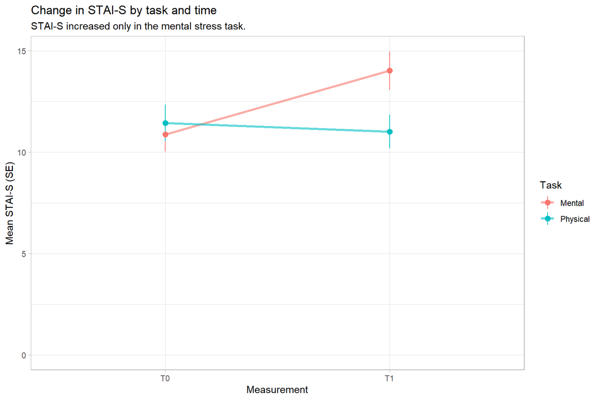

## Subjective stress (VAS)

Most of the participants regarded the mental stress more stressful than the physical stress.

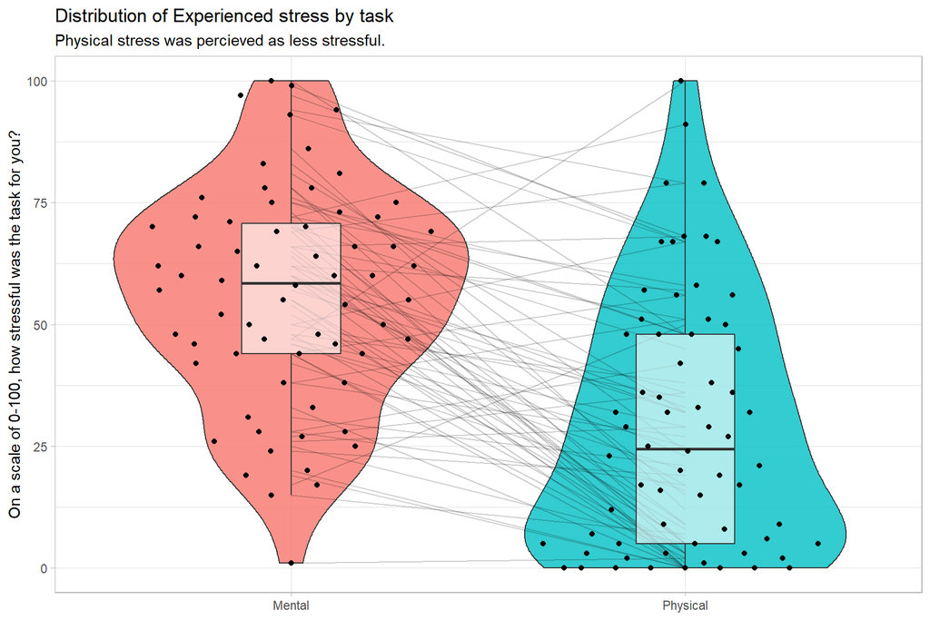

# Psychophysiological response to stress

## Outlier detection

We first flag outliers (calculated as outside of 3 SDs), and check how many can be found in each metric.

| Name | N outlier | % outlier |
| --- | --- | --- |
| hf_abs | 6 | 2.34% |
| rmssd | 6 | 2.34% |
| scl_increase | 6 | 2.31% |
| scr_avg | 5 | 1.92% |
| lf_abs | 4 | 1.56% |
| nn50 | 4 | 1.56% |
| p_nn50 | 4 | 1.56% |
| sdnn | 4 | 1.56% |
| vlf_abs | 4 | 1.56% |
| eda_avg | 4 | 1.54% |
| eda_increase | 4 | 1.54% |
| scl_avg | 4 | 1.54% |
| scr_increase | 4 | 1.54% |
| hf_percent | 3 | 1.17% |
| lf_hf | 3 | 1.17% |
| meanrr | 1 | 0.39% |
| medianrr | 1 | 0.39% |
| hf_n_u | 0 | 0.00% |
| lf_n_u | 0 | 0.00% |
| lf_percent | 0 | 0.00% |
| meanhr | 0 | 0.00% |
| vlf_percent | 0 | 0.00% |

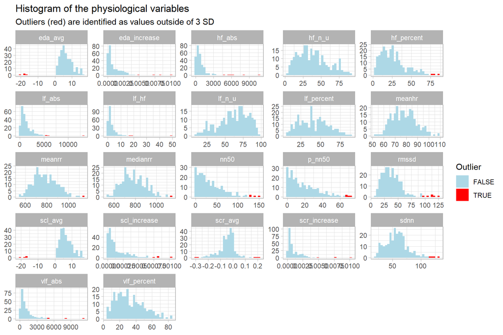

## Data cleaning and processing

We remove outliers, and apply natural log+1 transformation on the values. Values show that the EDA and SCR increase variables should be analyzed using a GLM with exponential distribution.

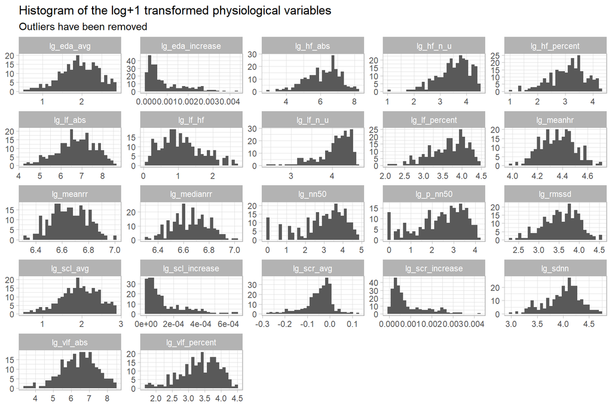

## Calculate physiological reactivity metrics

Reactivity values were calculated for HR, HF%, RMSSD, and EDA, by subtracting the baseline (t0) from the post-stress measurement (t1) for each task.

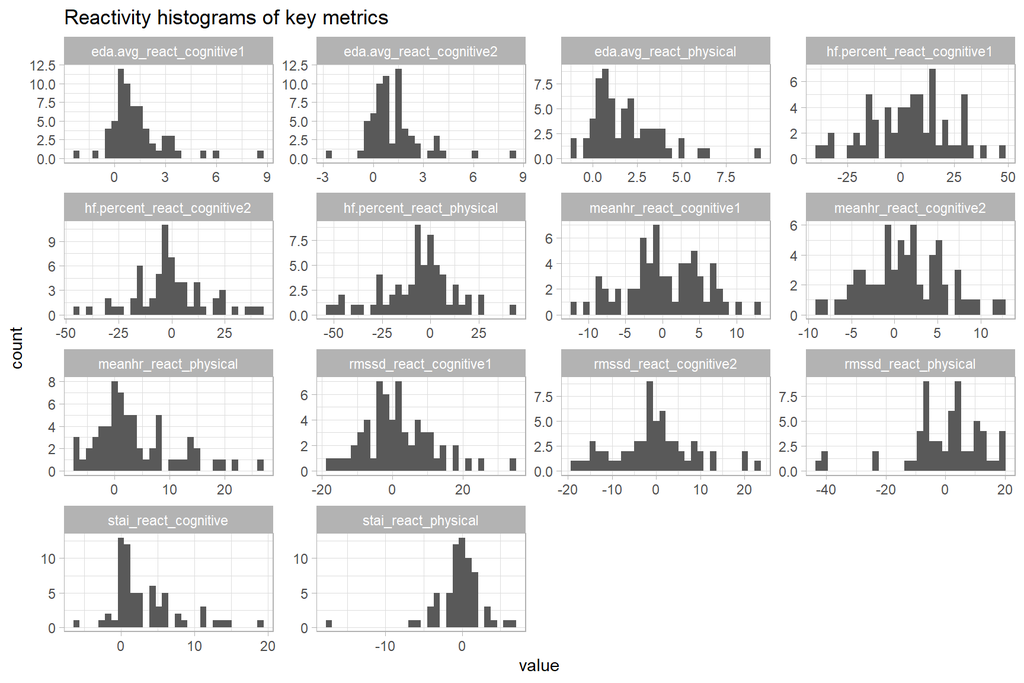

## Missing data analysis

```
## # A tibble: 22 x 3
##    variable     n_miss pct_miss
##    <chr>         <int>    <dbl>
##  1 meanrr            4     1.54
##  2 medianrr          4     1.54
##  3 meanhr            4     1.54
##  4 sdnn              4     1.54
##  5 rmssd             4     1.54
##  6 nn50              4     1.54
##  7 p_nn50            4     1.54
##  8 vlf_percent       4     1.54
##  9 lf_percent        4     1.54
## 10 hf_percent        4     1.54
## 11 lf_hf             4     1.54
## 12 lf_n_u            4     1.54
## 13 hf_n_u            4     1.54
## 14 vlf_abs           4     1.54
## 15 lf_abs            4     1.54
## 16 hf_abs            4     1.54
## 17 eda_avg           0     0
## 18 eda_increase      0     0
## 19 scr_avg           0     0
## 20 scr_increase      0     0
## 21 scl_avg           0     0
## 22 scl_increase      0     0
```

# Analysis of the effects of the tasks on physiological variables

## Heart rate related variables

### Variables

Heart rate and HRV variables were investigated using linear mixed-effect models, with random intercept by person. HRV variables were log+1 transformed to correct for right skew.

### Results

HR was increased in the physical task compared to baseline. log(RMSSD) did not change significantly in any task. log(HF%) and log(HF natural unit) shows a difference from baseline in cognitive1 (increase), and physical task (decrease). Sex, task order, and bodyfat percent were controlled, and were not significant predictors (age has little variability in the sample).

|  | lg_rmssd |  |  | lg_hf_percent |  |  | lg_hf_n_u |  |  | meanhr |  |  |
| --- | --- | --- | --- | --- | --- | --- | --- | --- | --- | --- | --- | --- |
| Predictors | Estimates | CI | p | Estimates | CI | p | Estimates | CI | p | Estimates | CI | p |
| (Intercept) | 3.59 | 3.40 – 3.79 | **<0.001** | 3.21 | 2.98 – 3.45 | **<0.001** | 3.65 | 3.43 – 3.87 | **<0.001** | 77.43 | 72.81 – 82.06 | **<0.001** |
| marker [cognitive1] | 0.04 | -0.03 – 0.11 | 0.259 | 0.23 | 0.06 – 0.40 | **0.010** | 0.27 | 0.12 – 0.42 | **<0.001** | 0.29 | -1.13 – 1.71 | 0.692 |
| marker [cognitive2] | -0.02 | -0.09 – 0.05 | 0.622 | 0.05 | -0.13 – 0.22 | 0.582 | 0.10 | -0.05 – 0.26 | 0.180 | 1.23 | -0.19 – 2.66 | 0.089 |
| marker [physical] | 0.02 | -0.05 – 0.09 | 0.559 | -0.20 | -0.38 – -0.03 | **0.022** | -0.16 | -0.31 – -0.01 | **0.036** | 3.64 | 2.22 – 5.06 | **<0.001** |
| task_order [Physical first] | -0.08 | -0.29 – 0.12 | 0.430 | -0.16 | -0.40 – 0.07 | 0.176 | -0.17 | -0.39 – 0.05 | 0.126 | 0.98 | -4.04 – 6.01 | 0.701 |
| sex [Male] | -0.01 | -0.28 – 0.26 | 0.941 | -0.13 | -0.44 – 0.17 | 0.385 | -0.23 | -0.51 – 0.06 | 0.118 | -2.35 | -8.83 – 4.13 | 0.477 |
| bodyfat_percent | -0.02 | -0.15 – 0.12 | 0.826 | -0.00 | -0.16 – 0.15 | 0.986 | 0.01 | -0.13 – 0.16 | 0.887 | 1.39 | -1.92 – 4.69 | 0.411 |
| Random Effects |  |  |  |  |  |  |  |  |  |  |  |  |
| σ<sup>2</sup> | 0.04 |  |  | 0.25 |  |  | 0.19 |  |  | 16.83 |  |  |
| τ<sub>00</sub> | 0.16 <sub>id</sub> |  |  | 0.16 <sub>id</sub> |  |  | 0.14 <sub>id</sub> |  |  | 95.69 <sub>id</sub> |  |  |
| ICC | 0.79 |  |  | 0.39 |  |  | 0.43 |  |  | 0.85 |  |  |
| N | 64 <sub>id</sub> |  |  | 64 <sub>id</sub> |  |  | 64 <sub>id</sub> |  |  | 64 <sub>id</sub> |  |  |
| Observations | 250 |  |  | 253 |  |  | 256 |  |  | 256 |  |  |
| Marginal R<sup>2</sup> / Conditional R<sup>2</sup> | 0.012 / 0.796 |  |  | 0.077 / 0.432 |  |  | 0.118 / 0.497 |  |  | 0.066 / 0.860 |  |  |
| AICc | 129.499 |  |  | 479.567 |  |  | 427.271 |  |  | 1648.208 |  |  |
| log-Likelihood | -55.375 |  |  | -230.413 |  |  | -204.270 |  |  | -814.738 |  |  |

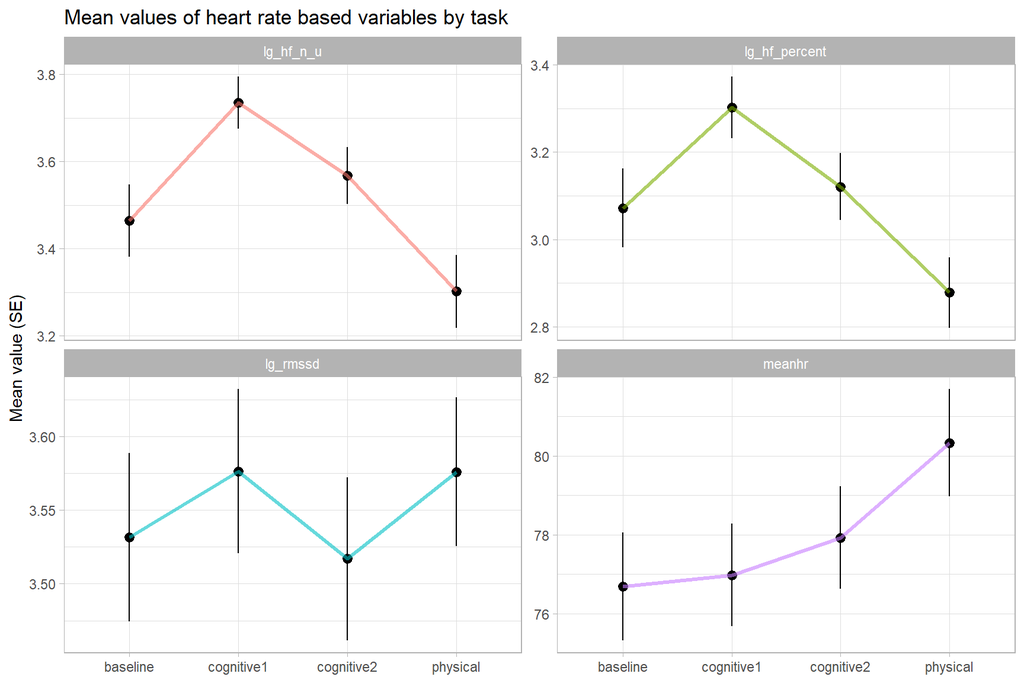

## Electrodermal response

### Variables

Raw electrodermal response was decomposed to tonic (SCL) and phasic (SCR) components. SCL was calculated by using the exponential moving average of the EDA values. The SCR values were calculated by taking the difference of EDA and SCL. We inspected the EDA, SCL, and SCR averages, and the increase value of these metrics. The averages were analyzed using linear mixed-effect models. The increase values are zero censored and heavily skewed, thus showing a gamma distribution. Therefore, we analyzed these values using generalized linear mixed-effect models, using a Gamma distribution with inverse link. Data had to be transformed to be applicable for statistical modeling. Average values were log+1 transformed and centered. Increase values were centered, then multiplied by 1000 for easier interpretation, then 1 is added to values to be larger than zero.

### Results

|  | lg_eda_avg |  |  | lg_scl_avg |  |  | lg_scr_avg |  |  | eda_increase |  |  | scl_increase |  |  | scr_increase |  |  |
| --- | --- | --- | --- | --- | --- | --- | --- | --- | --- | --- | --- | --- | --- | --- | --- | --- | --- | --- |
| Predictors | Estimates | CI | p | Estimates | CI | p | Estimates | CI | p | Estimates | CI | p | Estimates | CI | p | Estimates | CI | p |
| (Intercept) | 0.50 | 0.28 – 0.72 | **<0.001** | 0.51 | 0.29 – 0.72 | **<0.001** | -1.32 | -1.34 – -1.30 | **<0.001** | 3.49 | 2.65 – 4.60 | **<0.001** | 7.44 | 5.83 – 9.50 | **<0.001** | 3.17 | 2.51 – 4.00 | **<0.001** |
| marker [cognitive1] | 0.18 | 0.13 – 0.23 | **<0.001** | 0.19 | 0.14 – 0.24 | **<0.001** | -0.02 | -0.04 – 0.00 | 0.069 | 0.94 | 0.86 – 1.02 | 0.155 | 1.05 | 0.94 – 1.18 | 0.361 | 0.93 | 0.87 – 1.00 | **0.043** |
| marker [cognitive2] | 0.18 | 0.13 – 0.23 | **<0.001** | 0.18 | 0.13 – 0.23 | **<0.001** | -0.02 | -0.04 – 0.00 | 0.085 | 0.98 | 0.89 – 1.07 | 0.671 | 1.07 | 0.95 – 1.19 | 0.257 | 0.96 | 0.90 – 1.04 | 0.328 |
| marker [physical] | 0.27 | 0.22 – 0.32 | **<0.001** | 0.27 | 0.22 – 0.32 | **<0.001** | -0.02 | -0.04 – 0.00 | 0.117 | 0.82 | 0.76 – 0.88 | **<0.001** | 0.88 | 0.79 – 0.98 | **0.016** | 0.82 | 0.77 – 0.87 | **<0.001** |
| task_order [Physical first] | -0.02 | -0.25 – 0.21 | 0.861 | -0.02 | -0.25 – 0.21 | 0.873 | -0.01 | -0.03 – 0.01 | 0.499 | 0.95 | 0.71 – 1.27 | 0.740 | 1.07 | 0.83 – 1.38 | 0.588 | 0.96 | 0.75 – 1.22 | 0.716 |
| sex [Male] | 0.01 | -0.30 – 0.31 | 0.967 | 0.00 | -0.30 – 0.30 | 0.993 | 0.03 | 0.01 – 0.06 | **0.019** | 1.24 | 0.85 – 1.80 | 0.261 | 1.13 | 0.81 – 1.56 | 0.479 | 1.24 | 0.90 – 1.70 | 0.192 |
| bodyfat_percent | 0.09 | -0.06 – 0.25 | 0.226 | 0.09 | -0.06 – 0.24 | 0.232 | 0.01 | -0.01 – 0.02 | 0.369 | 1.02 | 0.84 – 1.24 | 0.812 | 1.00 | 0.85 – 1.18 | 0.970 | 1.03 | 0.87 – 1.21 | 0.757 |
| Random Effects |  |  |  |  |  |  |  |  |  |  |  |  |  |  |  |  |  |  |
| σ<sup>2</sup> | 0.02 |  |  | 0.02 |  |  | 0.00 |  |  | 0.18 |  |  | 0.04 |  |  | 0.13 |  |  |
| τ<sub>00</sub> | 0.21 <sub>id</sub> |  |  | 0.21 <sub>id</sub> |  |  | 0.00 <sub>id</sub> |  |  | 0.13 <sub>id</sub> |  |  | 0.08 <sub>id</sub> |  |  | 0.09 <sub>id</sub> |  |  |
| ICC | 0.91 |  |  | 0.91 |  |  | 0.16 |  |  | 0.43 |  |  | 0.69 |  |  | 0.42 |  |  |
| N | 64 <sub>id</sub> |  |  | 64 <sub>id</sub> |  |  | 65 <sub>id</sub> |  |  | 64 <sub>id</sub> |  |  | 65 <sub>id</sub> |  |  | 64 <sub>id</sub> |  |  |
| Observations | 256 |  |  | 256 |  |  | 255 |  |  | 256 |  |  | 254 |  |  | 256 |  |  |
| Marginal R<sup>2</sup> / Conditional R<sup>2</sup> | 0.072 / 0.916 |  |  | 0.073 / 0.915 |  |  | 0.051 / 0.207 |  |  | 0.048 / 0.457 |  |  | 0.078 / 0.717 |  |  | 0.062 / 0.459 |  |  |
| AICc | 18.979 |  |  | 19.342 |  |  | -621.565 |  |  | 276.781 |  |  | -467.834 |  |  | 217.197 |  |  |
| log-Likelihood | -0.124 |  |  | -0.305 |  |  | 320.150 |  |  | -129.025 |  |  | 243.286 |  |  | -99.232 |  |  |

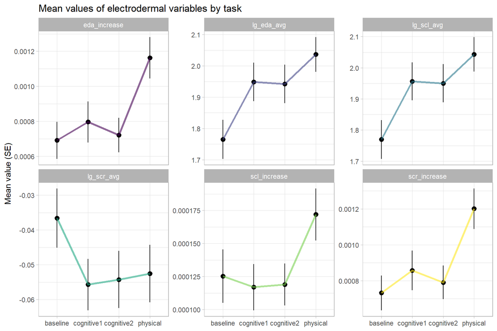

## Reactivity measures

### Variables

Reactivity (task - baseline) values were calculated for EDA average, HF%, RMSSD, HR average, and STAI.

### Results

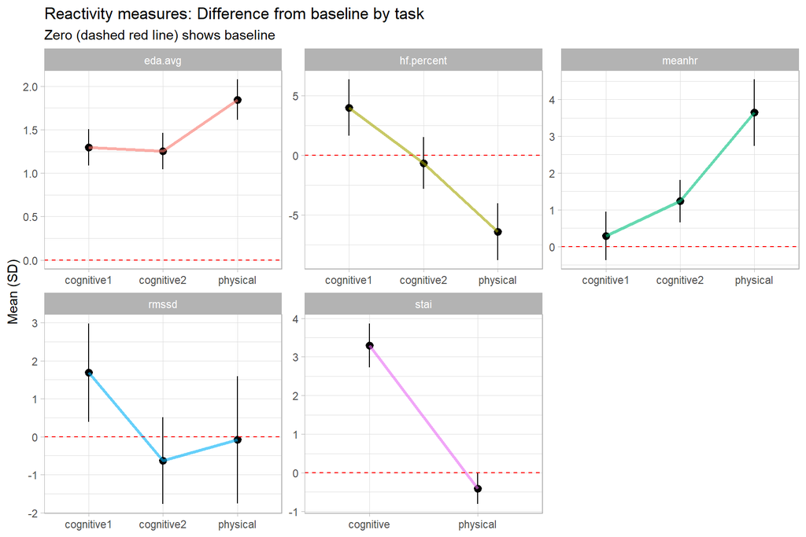

# Hypothesis tests

## H1

There is a medium level association between cardioceptive accuracy [cardioceptive_accuracy] and cardiovascular reactivity (positive for heart rate [ΔHRmental, ΔHRphysical], electrodermal response [SCRmental; SCRphysical]; negative for vagal component of heart rate variability [ΔRMSSDmental, ΔHFmental; ΔRMSSDphysical, ΔHFphysical]) in both conditions (mental; physical)

### Verbatim solution

We calculated the reactivity values, and correlated those with cardioceptive accuracy/bias, and heart rate perception.

Correlation Matrix (pearson-method)

| Parameter1 | Parameter2 | r | 95% CI | t | df | p |
| --- | --- | --- | --- | --- | --- | --- |
| meanhr_cognitive1 | ca | -0.07 | (-0.31, 0.18) | -0.55 | 62 | 0.746 |
| meanhr_cognitive2 | ca | 0.06 | (-0.19, 0.30) | 0.49 | 62 | 0.770 |
| meanhr_physical | ca | -0.08 | (-0.32, 0.17) | -0.62 | 62 | 0.746 |
| hf.percent_cognitive1 | ca | 0.05 | (-0.20, 0.29) | 0.39 | 61 | 0.797 |
| hf.percent_cognitive2 | ca | 0.10 | (-0.15, 0.34) | 0.77 | 61 | 0.691 |
| hf.percent_physical | ca | 0.03 | (-0.22, 0.27) | 0.22 | 61 | 0.898 |
| rmssd_cognitive1 | ca | -0.11 | (-0.36, 0.14) | -0.88 | 59 | 0.663 |
| rmssd_cognitive2 | ca | -0.19 | (-0.42, 0.06) | -1.50 | 59 | 0.396 |
| rmssd_physical | ca | -0.15 | (-0.39, 0.10) | -1.18 | 60 | 0.516 |
| eda.avg_cognitive1 | ca | 0.14 | (-0.11, 0.38) | 1.15 | 62 | 0.526 |
| eda.avg_cognitive2 | ca | 0.10 | (-0.15, 0.33) | 0.76 | 62 | 0.691 |
| eda.avg_physical | ca | 0.10 | (-0.15, 0.34) | 0.79 | 62 | 0.690 |
| stai_cognitive | ca | 0.03 | (-0.22, 0.27) | 0.21 | 62 | 0.901 |
| stai_physical | ca | -0.02 | (-0.26, 0.23) | -0.15 | 63 | 0.924 |
| meanhr_cognitive1 | cb | -0.07 | (-0.31, 0.18) | -0.55 | 62 | 0.746 |
| meanhr_cognitive2 | cb | 0.06 | (-0.19, 0.30) | 0.50 | 62 | 0.770 |
| meanhr_physical | cb | -0.08 | (-0.32, 0.17) | -0.61 | 62 | 0.746 |
| hf.percent_cognitive1 | cb | 0.05 | (-0.20, 0.30) | 0.41 | 61 | 0.797 |
| hf.percent_cognitive2 | cb | 0.10 | (-0.15, 0.34) | 0.77 | 61 | 0.690 |
| hf.percent_physical | cb | 0.03 | (-0.22, 0.27) | 0.22 | 61 | 0.898 |
| rmssd_cognitive1 | cb | -0.11 | (-0.36, 0.14) | -0.88 | 59 | 0.663 |
| rmssd_cognitive2 | cb | -0.19 | (-0.42, 0.06) | -1.51 | 59 | 0.396 |
| rmssd_physical | cb | -0.15 | (-0.39, 0.10) | -1.20 | 60 | 0.506 |
| eda.avg_cognitive1 | cb | 0.14 | (-0.11, 0.38) | 1.13 | 62 | 0.526 |
| eda.avg_cognitive2 | cb | 0.09 | (-0.16, 0.33) | 0.74 | 62 | 0.696 |
| eda.avg_physical | cb | 0.10 | (-0.15, 0.34) | 0.78 | 62 | 0.690 |
| stai_cognitive | cb | 0.03 | (-0.22, 0.27) | 0.20 | 62 | 0.901 |
| stai_physical | cb | -0.02 | (-0.26, 0.23) | -0.15 | 63 | 0.924 |
| meanhr_cognitive1 | hrp | 0.16 | (-0.09, 0.39) | 1.24 | 62 | 0.491 |
| meanhr_cognitive2 | hrp | 0.14 | (-0.11, 0.37) | 1.13 | 62 | 0.526 |
| meanhr_physical | hrp | 0.13 | (-0.12, 0.37) | 1.07 | 62 | 0.556 |
| hf.percent_cognitive1 | hrp | 0.21 | (-0.04, 0.44) | 1.68 | 61 | 0.346 |
| hf.percent_cognitive2 | hrp | 0.15 | (-0.11, 0.38) | 1.15 | 61 | 0.526 |
| hf.percent_physical | hrp | 0.11 | (-0.14, 0.35) | 0.87 | 61 | 0.663 |
| rmssd_cognitive1 | hrp | -0.05 | (-0.30, 0.20) | -0.40 | 59 | 0.797 |
| rmssd_cognitive2 | hrp | 0.08 | (-0.17, 0.33) | 0.64 | 59 | 0.746 |
| rmssd_physical | hrp | -0.10 | (-0.35, 0.15) | -0.81 | 60 | 0.677 |
| eda.avg_cognitive1 | hrp | 0.11 | (-0.14, 0.35) | 0.88 | 62 | 0.663 |
| eda.avg_cognitive2 | hrp | 0.16 | (-0.09, 0.39) | 1.24 | 62 | 0.491 |
| eda.avg_physical | hrp | -9.79e-03 | (-0.25, 0.24) | -0.08 | 62 | 0.960 |
| stai_cognitive | hrp | -0.11 | (-0.35, 0.14) | -0.87 | 62 | 0.663 |
| stai_physical | hrp | -0.26 | (-0.47, -0.01) | -2.10 | 63 | 0.182 |

p-value adjustment method: Benjamini & Hochberg (1995)  
Observations: 61-65

### Same thing, but more contemporary approach

We built linear mixed-effect models with random intercept by person to investigate if cardioceptive accuracy/bias/heart rate perception moderates the response to stress in any of the tasks.

Models for cardioceptive accuracy

|  | meanhr |  |  |  |  | lg_hf_percent |  |  |  |  | lg_rmssd |  |  |  |  | lg_eda_avg |  |  |  |  |
| --- | --- | --- | --- | --- | --- | --- | --- | --- | --- | --- | --- | --- | --- | --- | --- | --- | --- | --- | --- | --- |
| Predictors | Estimates | CI | df | Statistic | p | Estimates | CI | df | Statistic | p | Estimates | CI | df | Statistic | p | Estimates | CI | df | Statistic | p |
| (Intercept) | -0.12 | -0.36 – 0.11 | 246.00 | -1.02 | 0.309 | -0.02 | -0.26 – 0.22 | 243.00 | -0.16 | 0.874 | 0.01 | -0.23 – 0.26 | 240.00 | 0.10 | 0.924 | -0.32 | -0.57 – -0.08 | 246.00 | -2.61 | **0.009** |
| marker [cognitive1] | 0.03 | -0.11 – 0.16 | 246.00 | 0.39 | 0.694 | 0.35 | 0.08 – 0.63 | 243.00 | 2.57 | **0.010** | 0.09 | -0.07 – 0.26 | 240.00 | 1.09 | 0.275 | 0.38 | 0.27 – 0.48 | 246.00 | 7.08 | **<0.001** |
| marker [cognitive2] | 0.12 | -0.02 – 0.25 | 246.00 | 1.70 | 0.090 | 0.08 | -0.20 – 0.35 | 243.00 | 0.55 | 0.586 | -0.05 | -0.21 – 0.12 | 240.00 | -0.53 | 0.596 | 0.36 | 0.26 – 0.47 | 246.00 | 6.85 | **<0.001** |
| marker [physical] | 0.34 | 0.21 – 0.47 | 246.00 | 5.00 | **<0.001** | -0.31 | -0.58 – -0.04 | 243.00 | -2.26 | **0.024** | 0.05 | -0.12 – 0.21 | 240.00 | 0.57 | 0.569 | 0.56 | 0.45 – 0.66 | 246.00 | 10.48 | **<0.001** |
| ca | -0.29 | -0.52 – -0.05 | 246.00 | -2.41 | **0.016** | -0.01 | -0.25 – 0.23 | 243.00 | -0.11 | 0.915 | 0.35 | 0.11 – 0.60 | 240.00 | 2.86 | **0.004** | 0.03 | -0.21 – 0.27 | 246.00 | 0.22 | 0.823 |
| marker [cognitive1] * ca | -0.03 | -0.17 – 0.10 | 246.00 | -0.50 | 0.614 | 0.12 | -0.15 – 0.38 | 243.00 | 0.85 | 0.396 | -0.09 | -0.26 – 0.07 | 240.00 | -1.08 | 0.278 | 0.04 | -0.06 – 0.15 | 246.00 | 0.80 | 0.422 |
| marker [cognitive2] * ca | 0.03 | -0.11 – 0.16 | 246.00 | 0.39 | 0.696 | 0.16 | -0.10 – 0.43 | 243.00 | 1.19 | 0.233 | -0.11 | -0.28 – 0.06 | 240.00 | -1.31 | 0.190 | 0.02 | -0.08 – 0.12 | 246.00 | 0.36 | 0.718 |
| marker [physical] * ca | -0.05 | -0.19 – 0.08 | 246.00 | -0.78 | 0.437 | 0.09 | -0.18 – 0.36 | 243.00 | 0.67 | 0.500 | -0.10 | -0.27 – 0.06 | 240.00 | -1.23 | 0.218 | -0.00 | -0.11 – 0.10 | 246.00 | -0.03 | 0.973 |
| Random Effects |  |  |  |  |  |  |  |  |  |  |  |  |  |  |  |  |  |  |  |  |
| σ<sup>2</sup> | 0.15 |  |  |  |  | 0.60 |  |  |  |  | 0.22 |  |  |  |  | 0.09 |  |  |  |  |
| τ<sub>00</sub> | 0.77 <sub>id</sub> |  |  |  |  | 0.37 <sub>id</sub> |  |  |  |  | 0.76 <sub>id</sub> |  |  |  |  | 0.89 <sub>id</sub> |  |  |  |  |
| ICC | 0.84 |  |  |  |  | 0.38 |  |  |  |  | 0.77 |  |  |  |  | 0.91 |  |  |  |  |
| N | 64 <sub>id</sub> |  |  |  |  | 64 <sub>id</sub> |  |  |  |  | 64 <sub>id</sub> |  |  |  |  | 64 <sub>id</sub> |  |  |  |  |
| Observations | 256 |  |  |  |  | 253 |  |  |  |  | 250 |  |  |  |  | 256 |  |  |  |  |
| Marginal R<sup>2</sup> / Conditional R<sup>2</sup> | 0.108 / 0.855 |  |  |  |  | 0.065 / 0.420 |  |  |  |  | 0.077 / 0.790 |  |  |  |  | 0.042 / 0.913 |  |  |  |  |
| AICc | 475.220 |  |  |  |  | 700.147 |  |  |  |  | 542.647 |  |  |  |  | 390.221 |  |  |  |  |

Models for cardioceptive bias

|  | meanhr |  |  |  |  | lg_hf_percent |  |  |  |  | lg_rmssd |  |  |  |  | lg_eda_avg |  |  |  |  |
| --- | --- | --- | --- | --- | --- | --- | --- | --- | --- | --- | --- | --- | --- | --- | --- | --- | --- | --- | --- | --- |
| Predictors | Estimates | CI | df | Statistic | p | Estimates | CI | df | Statistic | p | Estimates | CI | df | Statistic | p | Estimates | CI | df | Statistic | p |
| (Intercept) | -0.12 | -0.36 – 0.11 | 246.00 | -1.02 | 0.308 | -0.02 | -0.26 – 0.22 | 243.00 | -0.16 | 0.874 | 0.01 | -0.23 – 0.26 | 240.00 | 0.10 | 0.924 | -0.32 | -0.57 – -0.08 | 246.00 | -2.61 | **0.009** |
| marker [cognitive1] | 0.03 | -0.11 – 0.16 | 246.00 | 0.39 | 0.694 | 0.35 | 0.08 – 0.63 | 243.00 | 2.57 | **0.010** | 0.09 | -0.07 – 0.26 | 240.00 | 1.09 | 0.275 | 0.38 | 0.27 – 0.48 | 246.00 | 7.08 | **<0.001** |
| marker [cognitive2] | 0.12 | -0.02 – 0.25 | 246.00 | 1.70 | 0.090 | 0.08 | -0.20 – 0.35 | 243.00 | 0.55 | 0.586 | -0.05 | -0.21 – 0.12 | 240.00 | -0.53 | 0.596 | 0.36 | 0.26 – 0.47 | 246.00 | 6.85 | **<0.001** |
| marker [physical] | 0.34 | 0.21 – 0.47 | 246.00 | 5.00 | **<0.001** | -0.31 | -0.58 – -0.04 | 243.00 | -2.26 | **0.024** | 0.05 | -0.12 – 0.21 | 240.00 | 0.57 | 0.569 | 0.56 | 0.45 – 0.66 | 246.00 | 10.48 | **<0.001** |
| cb | -0.29 | -0.52 – -0.06 | 246.00 | -2.42 | **0.015** | -0.01 | -0.25 – 0.23 | 243.00 | -0.10 | 0.918 | 0.36 | 0.11 – 0.60 | 240.00 | 2.87 | **0.004** | 0.03 | -0.21 – 0.27 | 246.00 | 0.23 | 0.822 |
| marker [cognitive1] * cb | -0.03 | -0.17 – 0.10 | 246.00 | -0.50 | 0.619 | 0.12 | -0.15 – 0.38 | 243.00 | 0.86 | 0.392 | -0.09 | -0.26 – 0.07 | 240.00 | -1.09 | 0.274 | 0.04 | -0.06 – 0.15 | 246.00 | 0.79 | 0.429 |
| marker [cognitive2] * cb | 0.03 | -0.11 – 0.16 | 246.00 | 0.40 | 0.689 | 0.16 | -0.10 – 0.43 | 243.00 | 1.20 | 0.232 | -0.11 | -0.28 – 0.05 | 240.00 | -1.32 | 0.187 | 0.02 | -0.09 – 0.12 | 246.00 | 0.35 | 0.729 |
| marker [physical] * cb | -0.05 | -0.18 – 0.08 | 246.00 | -0.76 | 0.445 | 0.09 | -0.18 – 0.36 | 243.00 | 0.67 | 0.503 | -0.10 | -0.27 – 0.06 | 240.00 | -1.25 | 0.212 | -0.00 | -0.11 – 0.10 | 246.00 | -0.04 | 0.969 |
| Random Effects |  |  |  |  |  |  |  |  |  |  |  |  |  |  |  |  |  |  |  |  |
| σ<sup>2</sup> | 0.15 |  |  |  |  | 0.60 |  |  |  |  | 0.22 |  |  |  |  | 0.09 |  |  |  |  |
| τ<sub>00</sub> | 0.77 <sub>id</sub> |  |  |  |  | 0.37 <sub>id</sub> |  |  |  |  | 0.76 <sub>id</sub> |  |  |  |  | 0.89 <sub>id</sub> |  |  |  |  |
| ICC | 0.84 |  |  |  |  | 0.38 |  |  |  |  | 0.77 |  |  |  |  | 0.91 |  |  |  |  |
| N | 64 <sub>id</sub> |  |  |  |  | 64 <sub>id</sub> |  |  |  |  | 64 <sub>id</sub> |  |  |  |  | 64 <sub>id</sub> |  |  |  |  |
| Observations | 256 |  |  |  |  | 253 |  |  |  |  | 250 |  |  |  |  | 256 |  |  |  |  |
| Marginal R<sup>2</sup> / Conditional R<sup>2</sup> | 0.109 / 0.855 |  |  |  |  | 0.065 / 0.420 |  |  |  |  | 0.078 / 0.790 |  |  |  |  | 0.042 / 0.913 |  |  |  |  |
| AICc | 475.179 |  |  |  |  | 700.120 |  |  |  |  | 542.556 |  |  |  |  | 390.245 |  |  |  |  |

Models for heart rate perception

|  | meanhr |  |  |  |  | lg_hf_percent |  |  |  |  | lg_rmssd |  |  |  |  | lg_eda_avg |  |  |  |  |
| --- | --- | --- | --- | --- | --- | --- | --- | --- | --- | --- | --- | --- | --- | --- | --- | --- | --- | --- | --- | --- |
| Predictors | Estimates | CI | df | Statistic | p | Estimates | CI | df | Statistic | p | Estimates | CI | df | Statistic | p | Estimates | CI | df | Statistic | p |
| (Intercept) | -0.12 | -0.33 – 0.09 | 246.00 | -1.13 | 0.257 | -0.02 | -0.26 – 0.22 | 243.00 | -0.17 | 0.864 | 0.01 | -0.21 – 0.24 | 240.00 | 0.11 | 0.914 | -0.32 | -0.57 – -0.08 | 246.00 | -2.62 | **0.009** |
| marker [cognitive1] | 0.03 | -0.11 – 0.16 | 246.00 | 0.39 | 0.694 | 0.36 | 0.09 – 0.63 | 243.00 | 2.60 | **0.009** | 0.09 | -0.07 – 0.26 | 240.00 | 1.09 | 0.274 | 0.38 | 0.27 – 0.48 | 246.00 | 7.17 | **<0.001** |
| marker [cognitive2] | 0.12 | -0.02 – 0.25 | 246.00 | 1.70 | 0.090 | 0.08 | -0.19 – 0.35 | 243.00 | 0.57 | 0.571 | -0.04 | -0.21 – 0.12 | 240.00 | -0.52 | 0.601 | 0.36 | 0.26 – 0.47 | 246.00 | 6.93 | **<0.001** |
| marker [physical] | 0.34 | 0.21 – 0.47 | 246.00 | 5.01 | **<0.001** | -0.31 | -0.58 – -0.04 | 243.00 | -2.26 | **0.024** | 0.05 | -0.12 – 0.21 | 240.00 | 0.55 | 0.584 | 0.56 | 0.45 – 0.66 | 246.00 | 10.61 | **<0.001** |
| hrp | -0.59 | -0.79 – -0.38 | 246.00 | -5.62 | **<0.001** | 0.09 | -0.15 – 0.33 | 243.00 | 0.75 | 0.454 | 0.51 | 0.29 – 0.74 | 240.00 | 4.45 | **<0.001** | 0.09 | -0.15 – 0.33 | 246.00 | 0.71 | 0.475 |
| marker [cognitive1] * hrp | 0.08 | -0.06 – 0.21 | 246.00 | 1.12 | 0.264 | 0.19 | -0.08 – 0.46 | 243.00 | 1.39 | 0.164 | -0.07 | -0.24 – 0.09 | 240.00 | -0.86 | 0.389 | 0.01 | -0.09 – 0.12 | 246.00 | 0.26 | 0.793 |
| marker [cognitive2] * hrp | 0.06 | -0.07 – 0.19 | 246.00 | 0.90 | 0.368 | 0.15 | -0.12 – 0.42 | 243.00 | 1.07 | 0.283 | 0.00 | -0.16 – 0.17 | 240.00 | 0.03 | 0.976 | 0.04 | -0.06 – 0.14 | 246.00 | 0.77 | 0.444 |
| marker [physical] * hrp | 0.09 | -0.04 – 0.22 | 246.00 | 1.32 | 0.185 | 0.16 | -0.11 – 0.42 | 243.00 | 1.15 | 0.251 | -0.15 | -0.31 – 0.02 | 240.00 | -1.77 | 0.077 | -0.07 | -0.18 – 0.03 | 246.00 | -1.44 | 0.150 |
| Random Effects |  |  |  |  |  |  |  |  |  |  |  |  |  |  |  |  |  |  |  |  |
| σ<sup>2</sup> | 0.15 |  |  |  |  | 0.60 |  |  |  |  | 0.22 |  |  |  |  | 0.09 |  |  |  |  |
| τ<sub>00</sub> | 0.56 <sub>id</sub> |  |  |  |  | 0.33 <sub>id</sub> |  |  |  |  | 0.63 <sub>id</sub> |  |  |  |  | 0.89 <sub>id</sub> |  |  |  |  |
| ICC | 0.79 |  |  |  |  | 0.36 |  |  |  |  | 0.74 |  |  |  |  | 0.91 |  |  |  |  |
| N | 64 <sub>id</sub> |  |  |  |  | 64 <sub>id</sub> |  |  |  |  | 64 <sub>id</sub> |  |  |  |  | 64 <sub>id</sub> |  |  |  |  |
| Observations | 256 |  |  |  |  | 253 |  |  |  |  | 250 |  |  |  |  | 256 |  |  |  |  |
| Marginal R<sup>2</sup> / Conditional R<sup>2</sup> | 0.301 / 0.855 |  |  |  |  | 0.105 / 0.423 |  |  |  |  | 0.207 / 0.793 |  |  |  |  | 0.048 / 0.915 |  |  |  |  |
| AICc | 456.894 |  |  |  |  | 694.219 |  |  |  |  | 529.087 |  |  |  |  | 385.512 |  |  |  |  |

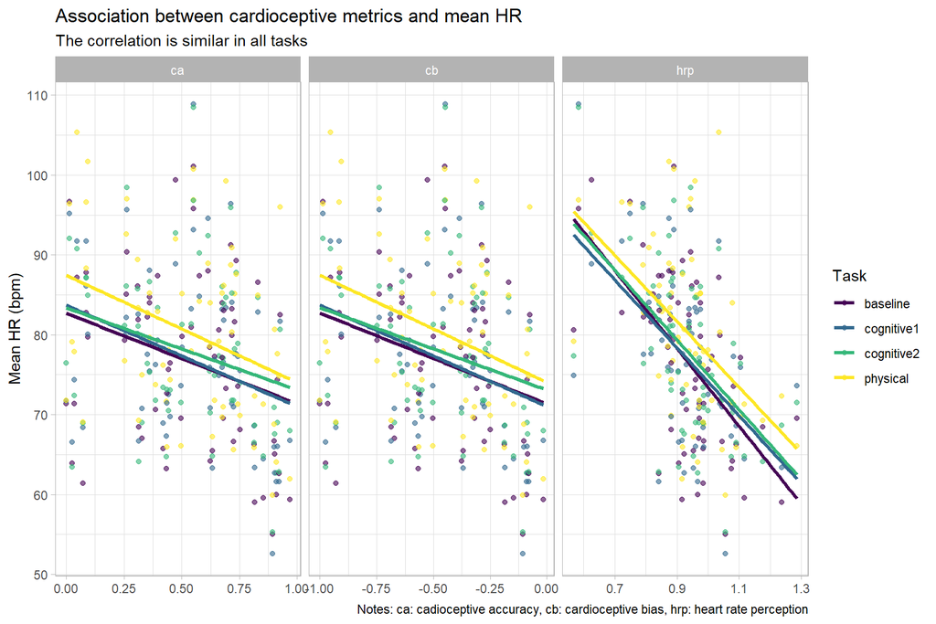

## H2

Cardioceptive accuracy [cardioceptive_accuracy] moderates the association between objective [ΔHRmental, SCRmental, ΔRMSSDmental, ΔHFmental; ΔHRphysical, SCRphysical, ΔRMSSDphysical, ΔHFphysical] and subjective reactions to stress [mental_experienced_stress; physical_experienced_stress / STAI-S_mental_after – STAI-S_mental_before; STAI-S_physical_after - STAI-S_physical_before]; higher cardioceptive accuracy is related to a stronger association

We fitted linear regressions on the reactivity score for each metric (HR mean, HF%, RMSSD, and EDA mean) for each task (cognitive1, cognitive2, and physical). We investigated if the STAI-S change in the respective task had a significant association with the change metric, and if the cardioceptive accuracy or heart rate perception moderated the association. We included sex, body fat percent, and task order as covariates.

We found a significant positive association between the reactivity of RMSSD in the cognitive task and the change in STAI. The higher the perceived stress was, the more the RMSSD increased in the cognitive task.

We found a significant negative association between the reactivity of EDA mean in the cognitive task and the change in STAI. The higher the perceived stress was, the more the EDA mean decreased in the cognitive task.

| term | estimate | std.error | conf.low | conf.high | statistic | p.value |
| --- | --- | --- | --- | --- | --- | --- |
| meanhr - cognitive1 - ca |  |  |  |  |  |  |
| (Intercept) | −0.01 | 0.24 | −0.48 | 0.46 | −0.044 | 0.965 |
| stai_react_cognitive | 0.02 | 0.14 | −0.26 | 0.31 | 0.160 | 0.873 |
| ca | −0.05 | 0.13 | −0.31 | 0.20 | −0.423 | 0.674 |
| bodyfat_percent | 0.06 | 0.17 | −0.29 | 0.40 | 0.337 | 0.737 |
| sexMale | 0.42 | 0.33 | −0.25 | 1.09 | 1.256 | 0.214 |
| task_orderPhysical first | −0.51 | 0.26 | −1.04 | 0.01 | −1.961 | 0.055 |
| stai_react_cognitive:ca | −0.06 | 0.16 | −0.38 | 0.26 | −0.383 | 0.703 |
| meanhr - cognitive1 - hrp |  |  |  |  |  |  |
| (Intercept) | 0.10 | 0.25 | −0.39 | 0.60 | 0.420 | 0.676 |
| stai_react_cognitive | 0.04 | 0.14 | −0.23 | 0.31 | 0.305 | 0.762 |
| hrp | 0.04 | 0.15 | −0.26 | 0.33 | 0.241 | 0.811 |
| bodyfat_percent | −0.01 | 0.18 | −0.38 | 0.36 | −0.048 | 0.962 |
| sexMale | 0.26 | 0.36 | −0.46 | 0.98 | 0.726 | 0.471 |
| task_orderPhysical first | −0.57 | 0.26 | −1.10 | −0.05 | −2.180 | 0.034 |
| stai_react_cognitive:hrp | 0.10 | 0.10 | −0.10 | 0.30 | 1.012 | 0.316 |
| meanhr - cognitive2 - ca |  |  |  |  |  |  |
| (Intercept) | −0.03 | 0.24 | −0.52 | 0.46 | −0.134 | 0.894 |
| stai_react_cognitive | 0.10 | 0.15 | −0.19 | 0.40 | 0.686 | 0.495 |
| ca | 0.07 | 0.13 | −0.20 | 0.34 | 0.532 | 0.597 |
| bodyfat_percent | 0.09 | 0.18 | −0.27 | 0.45 | 0.479 | 0.634 |
| sexMale | 0.31 | 0.35 | −0.39 | 1.00 | 0.887 | 0.379 |
| task_orderPhysical first | −0.30 | 0.27 | −0.85 | 0.24 | −1.114 | 0.270 |
| stai_react_cognitive:ca | −0.02 | 0.16 | −0.34 | 0.31 | −0.100 | 0.921 |
| meanhr - cognitive2 - hrp |  |  |  |  |  |  |
| (Intercept) | 0.09 | 0.26 | −0.42 | 0.61 | 0.355 | 0.724 |
| stai_react_cognitive | 0.15 | 0.14 | −0.13 | 0.43 | 1.071 | 0.289 |
| hrp | 0.05 | 0.15 | −0.25 | 0.36 | 0.354 | 0.725 |
| bodyfat_percent | −0.02 | 0.19 | −0.40 | 0.36 | −0.104 | 0.917 |
| sexMale | 0.12 | 0.37 | −0.63 | 0.86 | 0.317 | 0.753 |

[output cut: 162 more lines]

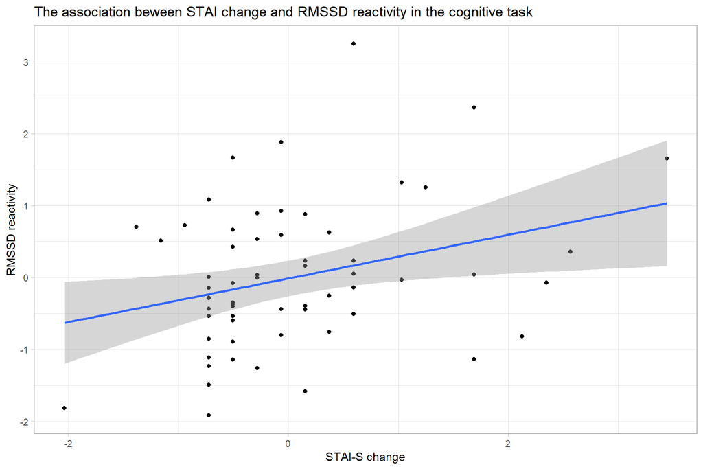

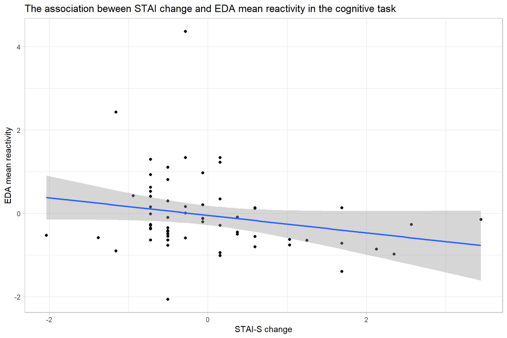

## H3

Perceived stress in both conditions [mental_experienced_stress; physical_experienced_stress / STAI-S_mental_after – STAI-S_mental_before; STAI-S_physical_after - STAI-S_physical_before] is predicted by cardioceptive accuracy [cardioceptive_accuracy], physiological reactions [ΔHRmental, SCRmental, ΔRMSSDmental, ΔHFmental; ΔHRphysical, SCRphysical, ΔRMSSDphysical, ΔHFphysical], and stress related expectations [mental_expected_stress; physical_expected_stress]

We fitted linear regressions for each task (cognitive1, cognitive2, and physical) separately. We investigated if physiological changes, cardioceptive accuracy, or expected HR change predicted STAI-S change in the respective tasks. We used task order as a covariate.

We found no associations between cardioceptive accuracy and STAI-S change. Expected HR change did predict STAI-S change in all cognitive tasks. From the physiological measures, only RMSSD predicted STAI-S change.

| term | estimate | std.error | conf.low | conf.high | statistic | p.value |
| --- | --- | --- | --- | --- | --- | --- |
| cognitive1_stai_meanhr |  |  |  |  |  |  |
| (Intercept) | −0.15 | 0.17 | −0.49 | 0.18 | −0.898 | 0.373 |
| ca | 0.02 | 0.13 | −0.23 | 0.27 | 0.182 | 0.856 |
| mental_expected_hr_change | 0.27 | 0.13 | 0.01 | 0.53 | 2.088 | 0.041 |
| task_orderPhysical first | 0.36 | 0.27 | −0.17 | 0.90 | 1.355 | 0.181 |
| meanhr | −0.04 | 0.13 | −0.30 | 0.22 | −0.305 | 0.761 |
| cognitive2_stai_meanhr |  |  |  |  |  |  |
| (Intercept) | −0.17 | 0.17 | −0.50 | 0.16 | −1.022 | 0.311 |
| ca | 0.02 | 0.13 | −0.23 | 0.27 | 0.139 | 0.890 |
| mental_expected_hr_change | 0.27 | 0.13 | 0.01 | 0.53 | 2.106 | 0.040 |
| task_orderPhysical first | 0.41 | 0.26 | −0.11 | 0.93 | 1.570 | 0.122 |
| meanhr | 0.09 | 0.13 | −0.16 | 0.34 | 0.700 | 0.487 |
| physical_stai_meanhr |  |  |  |  |  |  |
| (Intercept) | −0.02 | 0.17 | −0.36 | 0.32 | −0.108 | 0.914 |
| ca | −0.03 | 0.13 | −0.29 | 0.23 | −0.226 | 0.822 |
| physical_expected_hr_change | 0.01 | 0.14 | −0.26 | 0.29 | 0.102 | 0.919 |
| task_orderPhysical first | 0.03 | 0.28 | −0.52 | 0.58 | 0.106 | 0.916 |
| meanhr | −0.11 | 0.13 | −0.38 | 0.15 | −0.854 | 0.397 |
| cognitive1_stai_hf.percent |  |  |  |  |  |  |
| (Intercept) | −0.16 | 0.16 | −0.48 | 0.16 | −0.999 | 0.322 |
| ca | 0.02 | 0.12 | −0.23 | 0.26 | 0.145 | 0.885 |
| mental_expected_hr_change | 0.34 | 0.13 | 0.08 | 0.61 | 2.582 | 0.012 |
| task_orderPhysical first | 0.39 | 0.25 | −0.12 | 0.89 | 1.524 | 0.133 |
| hf.percent | 0.23 | 0.13 | −0.03 | 0.49 | 1.790 | 0.079 |
| cognitive2_stai_hf.percent |  |  |  |  |  |  |
| (Intercept) | −0.16 | 0.17 | −0.49 | 0.17 | −0.948 | 0.347 |
| ca | 0.03 | 0.13 | −0.23 | 0.28 | 0.213 | 0.832 |
| mental_expected_hr_change | 0.27 | 0.13 | 0.00 | 0.53 | 2.005 | 0.050 |
| task_orderPhysical first | 0.38 | 0.26 | −0.14 | 0.90 | 1.464 | 0.149 |
| hf.percent | −0.03 | 0.13 | −0.29 | 0.23 | −0.233 | 0.816 |
| physical_stai_hf.percent |  |  |  |  |  |  |
| (Intercept) | 0.00 | 0.17 | −0.34 | 0.35 | 0.020 | 0.984 |
| ca | −0.03 | 0.13 | −0.29 | 0.22 | −0.252 | 0.802 |
| physical_expected_hr_change | −0.01 | 0.13 | −0.27 | 0.26 | −0.052 | 0.959 |
| task_orderPhysical first | 0.05 | 0.29 | −0.52 | 0.63 | 0.187 | 0.852 |
| hf.percent | −0.13 | 0.14 | −0.40 | 0.14 | −0.949 | 0.346 |
| cognitive1_stai_rmssd |  |  |  |  |  |  |
| (Intercept) | −0.10 | 0.16 | −0.41 | 0.21 | −0.646 | 0.521 |
| ca | 0.12 | 0.12 | −0.12 | 0.36 | 0.978 | 0.332 |
| mental_expected_hr_change | 0.33 | 0.12 | 0.09 | 0.58 | 2.697 | 0.009 |
| task_orderPhysical first | 0.33 | 0.25 | −0.17 | 0.82 | 1.331 | 0.189 |
| rmssd | 0.36 | 0.12 | 0.12 | 0.61 | 2.982 | 0.004 |
| cognitive2_stai_rmssd |  |  |  |  |  |  |
| (Intercept) | −0.12 | 0.16 | −0.44 | 0.20 | −0.774 | 0.442 |
| ca | 0.13 | 0.13 | −0.12 | 0.38 | 1.036 | 0.304 |
| mental_expected_hr_change | 0.32 | 0.13 | 0.06 | 0.57 | 2.513 | 0.015 |
| task_orderPhysical first | 0.39 | 0.25 | −0.12 | 0.89 | 1.532 | 0.131 |
| rmssd | 0.30 | 0.13 | 0.05 | 0.55 | 2.384 | 0.021 |
| physical_stai_rmssd |  |  |  |  |  |  |
| (Intercept) | 0.02 | 0.17 | −0.32 | 0.36 | 0.115 | 0.909 |
| ca | −0.07 | 0.13 | −0.33 | 0.19 | −0.510 | 0.612 |
| physical_expected_hr_change | 0.02 | 0.13 | −0.25 | 0.29 | 0.158 | 0.875 |
| task_orderPhysical first | 0.00 | 0.27 | −0.55 | 0.55 | −0.015 | 0.988 |
| rmssd | −0.18 | 0.13 | −0.44 | 0.09 | −1.326 | 0.190 |
| cognitive1_stai_eda.avg |  |  |  |  |  |  |
| (Intercept) | −0.17 | 0.16 | −0.49 | 0.15 | −1.085 | 0.282 |
| ca | 0.07 | 0.12 | −0.18 | 0.32 | 0.574 | 0.568 |
| mental_expected_hr_change | 0.28 | 0.12 | 0.03 | 0.53 | 2.263 | 0.027 |
| task_orderPhysical first | 0.37 | 0.25 | −0.14 | 0.87 | 1.443 | 0.154 |
| eda.avg | −0.26 | 0.13 | −0.52 | 0.00 | −1.965 | 0.054 |
| cognitive2_stai_eda.avg |  |  |  |  |  |  |
| (Intercept) | −0.16 | 0.16 | −0.49 | 0.16 | −1.003 | 0.320 |
| ca | 0.05 | 0.12 | −0.20 | 0.30 | 0.404 | 0.688 |
| mental_expected_hr_change | 0.28 | 0.13 | 0.03 | 0.53 | 2.206 | 0.031 |
| task_orderPhysical first | 0.35 | 0.26 | −0.17 | 0.86 | 1.352 | 0.182 |
| eda.avg | −0.18 | 0.13 | −0.45 | 0.09 | −1.316 | 0.193 |
| physical_stai_eda.avg |  |  |  |  |  |  |
| (Intercept) | −0.02 | 0.17 | −0.36 | 0.33 | −0.104 | 0.918 |
| ca | −0.03 | 0.13 | −0.30 | 0.24 | −0.237 | 0.813 |
| physical_expected_hr_change | 0.00 | 0.14 | −0.27 | 0.28 | 0.032 | 0.974 |
| task_orderPhysical first | 0.05 | 0.28 | −0.51 | 0.61 | 0.185 | 0.854 |
| eda.avg | 0.08 | 0.13 | −0.19 | 0.34 | 0.579 | 0.565 |

## H4

Perceived HR in both conditions [mental_experienced_HR_change; physical_experienced_HR_change] is predicted by actual change [ΔHRmental, ΔHRphysical] and HR-related expectations [mental_expected_HR_change; physical_expected_HR_change] in both conditions

We fitted linear regressions for each task (cognitive1, cognitive2, and physical) separately. We investigated if actual (ECG measured) HR change in the respective tasks predicted subjective HR change, and if expectations predicted subjective HR change better. We included sex, body fat percent, and task order as covariates.

We found that actual HR change did not predict the experienced HR change in any of the tasks. However, expected HR change significantly predicted subjective HR change in all tasks.

| term | estimate | std.error | conf.low | conf.high | statistic | p.value |
| --- | --- | --- | --- | --- | --- | --- |
| cognitive1_by_expected |  |  |  |  |  |  |
| (Intercept) | −0.01 | 0.22 | −0.45 | 0.42 | −0.066 | 0.948 |
| mental_expected_hr_change | 0.47 | 0.12 | 0.24 | 0.71 | 3.977 | 0.000 |
| bodyfat_percent | 0.15 | 0.15 | −0.16 | 0.46 | 0.988 | 0.327 |
| sexMale | −0.05 | 0.31 | −0.66 | 0.56 | −0.167 | 0.868 |
| task_orderPhysical first | 0.06 | 0.23 | −0.41 | 0.53 | 0.263 | 0.793 |
| cognitive1_by_react |  |  |  |  |  |  |
| (Intercept) | 0.24 | 0.23 | −0.23 | 0.71 | 1.024 | 0.310 |
| hr_reactivity | 0.10 | 0.13 | −0.17 | 0.37 | 0.719 | 0.475 |
| bodyfat_percent | 0.03 | 0.17 | −0.31 | 0.38 | 0.186 | 0.853 |
| sexMale | −0.39 | 0.34 | −1.07 | 0.29 | −1.153 | 0.253 |
| task_orderPhysical first | −0.09 | 0.27 | −0.63 | 0.45 | −0.349 | 0.728 |
| cognitive2_by_expected |  |  |  |  |  |  |
| (Intercept) | −0.01 | 0.22 | −0.45 | 0.42 | −0.066 | 0.948 |
| mental_expected_hr_change | 0.47 | 0.12 | 0.24 | 0.71 | 3.977 | 0.000 |
| bodyfat_percent | 0.15 | 0.15 | −0.16 | 0.46 | 0.988 | 0.327 |
| sexMale | −0.05 | 0.31 | −0.66 | 0.56 | −0.167 | 0.868 |
| task_orderPhysical first | 0.06 | 0.23 | −0.41 | 0.53 | 0.263 | 0.793 |
| cognitive2_by_react |  |  |  |  |  |  |
| (Intercept) | 0.25 | 0.24 | −0.23 | 0.72 | 1.043 | 0.301 |
| hr_reactivity | 0.07 | 0.13 | −0.19 | 0.33 | 0.531 | 0.598 |
| bodyfat_percent | 0.03 | 0.17 | −0.31 | 0.38 | 0.188 | 0.851 |
| sexMale | −0.37 | 0.34 | −1.05 | 0.30 | −1.103 | 0.275 |
| task_orderPhysical first | −0.13 | 0.26 | −0.65 | 0.40 | −0.493 | 0.624 |
| physical_by_expected |  |  |  |  |  |  |
| (Intercept) | 0.27 | 0.22 | −0.17 | 0.70 | 1.238 | 0.221 |
| physical_expected_hr_change | 0.33 | 0.12 | 0.08 | 0.57 | 2.696 | 0.009 |
| bodyfat_percent | 0.17 | 0.16 | −0.14 | 0.49 | 1.121 | 0.267 |
| sexMale | −0.31 | 0.31 | −0.92 | 0.31 | −0.999 | 0.322 |
| task_orderPhysical first | −0.27 | 0.24 | −0.76 | 0.21 | −1.131 | 0.263 |
| physical_by_react |  |  |  |  |  |  |
| (Intercept) | 0.19 | 0.23 | −0.27 | 0.64 | 0.819 | 0.416 |
| hr_reactivity | 0.10 | 0.13 | −0.15 | 0.35 | 0.816 | 0.418 |
| bodyfat_percent | 0.22 | 0.17 | −0.12 | 0.55 | 1.298 | 0.199 |
| sexMale | −0.27 | 0.32 | −0.92 | 0.38 | −0.825 | 0.413 |
| task_orderPhysical first | −0.14 | 0.25 | −0.65 | 0.36 | −0.572 | 0.570 |

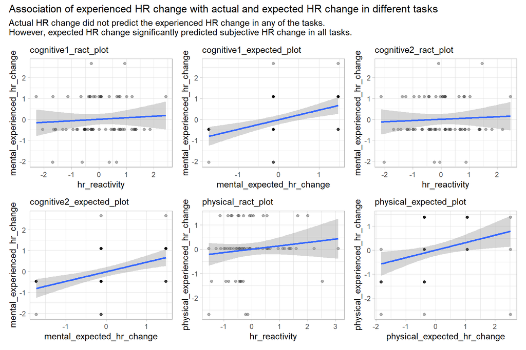

## H5

Acuity of perception of heartbeat [cardioceptive_bias] and heart rate [cardioceptive_accuracy_HR] are positively associated

There is a positive correlation between cardioceptive accuracy, caridoceptive bias, but not between cardioceptive metrics and heart rate perception.

Correlation Matrix (pearson-method)

| Parameter1 | Parameter2 | r | 95% CI | t(63) | p |
| --- | --- | --- | --- | --- | --- |
| ca | cb | 1.00 | (1.00, 1.00) | 834.44 | < .001*** |
| ca | hrp | 0.16 | (-0.09, 0.39) | 1.29 | 0.204 |
| cb | hrp | 0.16 | (-0.09, 0.39) | 1.28 | 0.204 |

p-value adjustment method: Benjamini & Hochberg (1995)  
Observations: 65